# Exponential Distribution and the Central Limit Theorem

Daniela Gracia

4/24/2021

**Statistical Inference Course Project: Part 1**

### Synopsis

In this project we will investigate the exponential distribution in R. Our goal is to answer the question: **¿Does the distribution of means of 40 exponentials behave as predicted by the Central Limit Theorem (CLT)?**. The structure for the analysis consists of a *(1) Simulation* section, where the data required for this analysis will be simulated, an *(2) Analysis* section where we study the question and a *(3) Conclusions* section.

### Simulations

In this section we will generate all the data necessary for the analysis. First we simulate and exponential distribution of 40000 observations and store it in the rows of a 1000x40 matrix we name “data”. We use a fixed rate parameter: $\lambda=0.2$ for all simulations.

```r
# Here we simulate an exponential distribution using rexp(), define the rate parameter (lambda), the mean, the standard deviation and the number of simulations N
lambda <- 0.2
theoretical_mean <- 1/lambda
s <- 1/lambda
N <- 1000
n <- 40
# set a seed to make our data reproducible
set.seed(1111)
# simulate an exponential distribution of n*N observations and store it in a 1000 x 40 matrix
data <- matrix(rexp(n*N, rate=lambda),ncol=n,nrow=N)
```

Now that we have an exponential distribution of 40000 observations organized in a 1000 row and 40 column matrix we will calculate the mean of each row and store it in the matrix “means”, we will use this later in the analysis.

```r
# using the simulated data we now create a matrix of the average of each distribution
means <- matrix(data=NA, nrow=N, ncol=1)
for (i in 1:N) {
        means[i,1] <- mean(data[i,])
}
```

Below is a histogram of the exponential distribution we simulated:

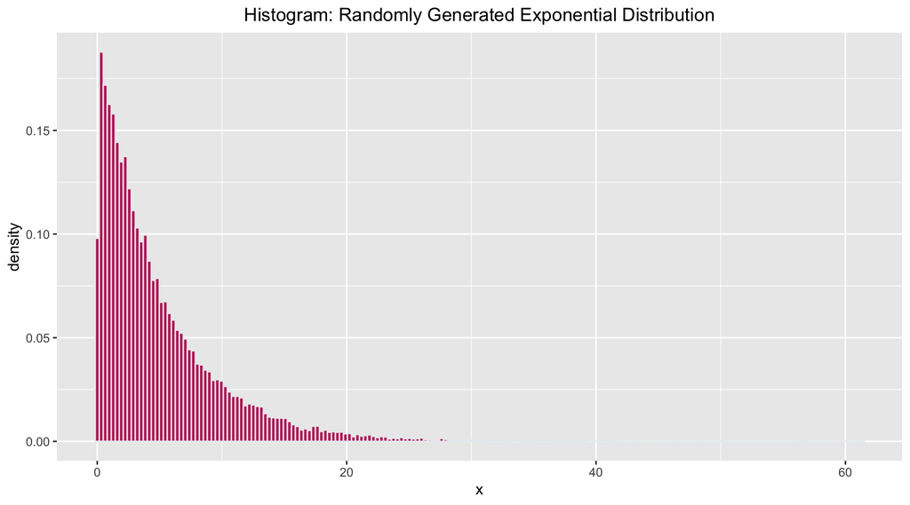

### Analysis

Now, we will use the data we simulated to study whether the distribution of means of 40 exponentials behaves as predicted by the Central Limit Theorem. In other words, we want to know if the distribution of averages of 40 exponentials behaves as a normal distribution.

#### Sample Mean VS Theoretical Mean

We will evaluate the sample mean vs the theoretical mean. By doing this we are investigating whether the hypothesized mean is supported by our data. Reversely, we want to know if our sample mean approaches the theoretical mean. In order to do this in a formal way we will test the following null and alternative hypotheses:

**Null Hypothesis:**
$$H_0: \mu=\mu_0$$
and we know that $\mu_0=\frac{1}{\lambda}$, if we use $\lambda=0.2$:

$$H_0: \mu=5$$
**Alternative Hypothesis:**
$$H_a: \mu\neq\mu_0\neq5$$
Now we will use the t.test() function to run a two sided test, calculate the 95% confidence interval, p-value, t-statistic and the sample mean.

```
##
##  One Sample t-test
##
## data:  means
## t = -0.20422, df = 999, p-value = 0.8382
## alternative hypothesis: true mean is not equal to 5
## 95 percent confidence interval:
##  4.945711 5.044055
## sample estimates:
## mean of x
##  4.994883
```

When evaluating the two sided test we can see that the absolute value of the t-statistic is *0.204* which is less than the $x_.975$ t-quantile *1.962*. Therefore we fail to reject the null hypothesis $H_0$ and accept it with a p-value of *0.838* which also supports this. Additionally the theoretical mean is well within the 95% confidence interval which means it is supported.

To illustrate we will display our distribution of averages in a histogram. The red vertical line represents the theoretical mean and the blue vertical line the sample mean. As we can see they are very close to each other and hard to discern. This confirms that the sample mean is approaching the population mean as the sample size increases and that we have 95% certainty that the theoretical mean is indeed the population mean. Additionally we will show that the theoretical mean (as well as the sample mean) are within the confidence interval. We have shaded the 95% confidence region in a darker shade of gray in the density plot below.

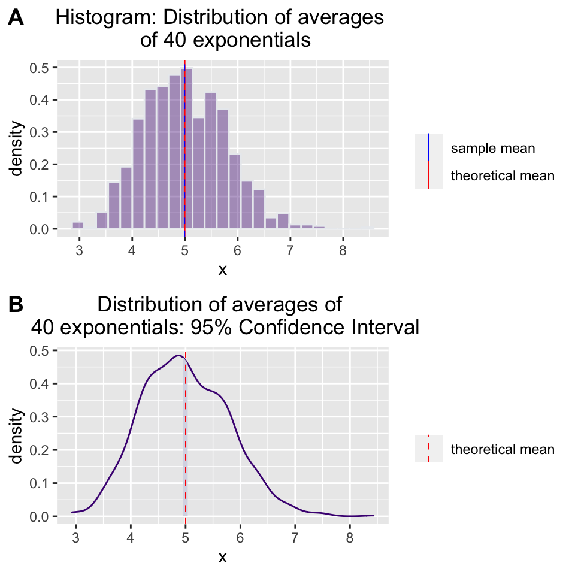

#### Sample Variance VS Theoretical Variance

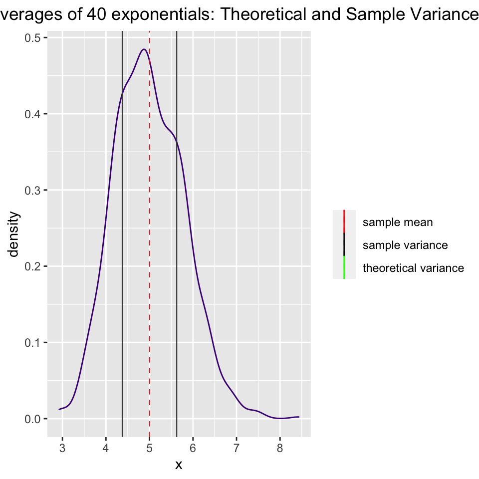

#### Distribution

In order to prove that the distribution is approximately normal we are going to compare it to a normal distribution with mean $\mu=5$ and variance $\sigma^2=0.625$. We will also pay attention to the difference between the distribution of a large collection of random exponentials and the distribution of a large collection of averages of 40 exponentials.

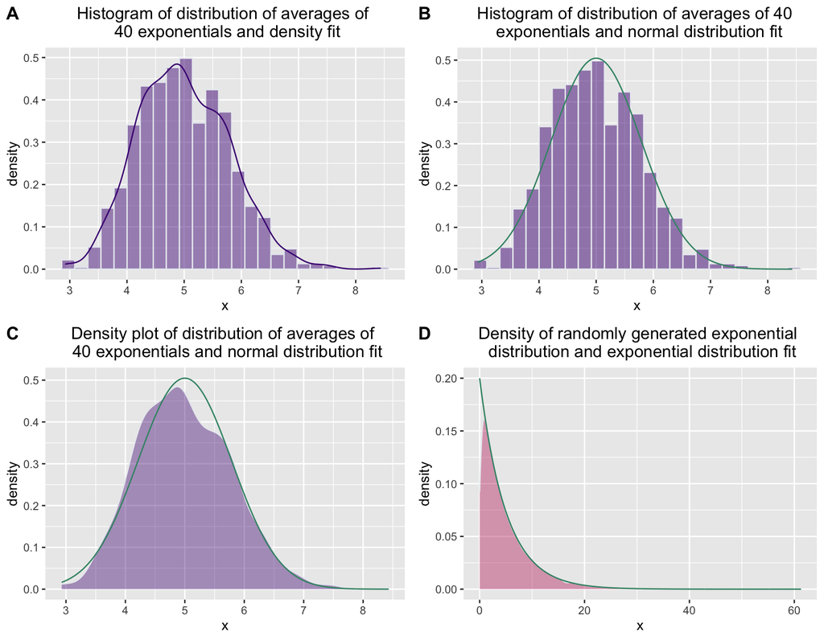

**Plot A:** Histogram and density plot of the distribution of means of 40 exponentials with $\lambda=0.2$ that we generated.

**Plot B:** Histogram of the distribution of means of 40 exponentials with $\lambda=0.2$ that we generated and normal distribution with mean $\mu=5$ and variance $\sigma^2=0.625$.

**Plot C:** Density plot of the distribution of means of 40 exponentials with $\lambda=0.2$ that we generated and normal distribution with mean $\mu=5$ and variance $\sigma^2=0.625$.

**Plot D:** Density plot of the random exponential distribution of 40000 observations we generated with $\lambda=0.2$ and exponential distribution fit with rate $\lambda=0.2$.

### Conclusions

Assuming our variables are statistically independent and identically distributed - drawn form the same population (IID) we conclude that our simulations behave as predicted by the Central Limit Theorem. Our analysis showed the following: 1)The mean and variance from our distribution of averages are consistent with the theoretical values 2) the T test we ran to study the mean gave us a near 1 p-value as well as a 95% confidence interval for the mean 3) our distribution is bell shaped and when compared to a normal distribution it is clear that they are very similar. Therefore, we conclude that the distribution of averages of 40 exponentials is normally distributed.